# Создание модели персонализиции предложения постоянным клиентам

## Сегментация покупателей

Для сегментации покупателей добавим в наш датасет *df* столбец `Вероятность_снижения` с предсказанными моделью значениями вероятности снижения покупательской активности.

Также добавим столбец со значениями прибыли из *df_money*.

```python
y_proba = randomized_search.predict_proba(X)[:,1]

df = X
df['Вероятность_снижения'] = y_proba.round(3)
df.head()
```

| id | Тип сервиса | Разрешить сообщать | Маркет_актив_6_мес | Маркет_актив_тек_мес | Длительность | Акционные_покупки | Популярная_категория | Средний_просмотр_категорий_за_визит | Неоплаченные_продукты_штук_квартал | Ошибка_сервиса | Страниц_за_визит | Выручка_предыдущий_месяц | Выручка_препредыдущий_месяц | Выручка_текущий_месяц | Минуты_предыдущий_месяц | Минуты_текущий_месяц | Вероятность_снижения |
| --- | --- | --- | --- | --- | --- | --- | --- | --- | --- | --- | --- | --- | --- | --- | --- | --- | --- |
| 215349 | Премиум | Да | 4.4 | 4 | 819 | 0.75 | Товары для детей | 4 | 4 | 2 | 5 | 5216.0 | 4472.0 | 4971.6 | 12 | 10 | 0.879 |
| 215350 | Стандарт | Нет | 4.9 | 3 | 539 | 0.14 | Домашний текстиль | 5 | 2 | 1 | 5 | 5457.5 | 4826.0 | 5058.4 | 8 | 13 | 0.649 |
| 215351 | Стандарт | Да | 3.2 | 5 | 896 | 0.99 | Товары для детей | 5 | 0 | 6 | 4 | 6158.0 | 4793.0 | 6610.4 | 11 | 13 | 0.925 |
| 215352 | Стандарт | Нет | 5.1 | 3 | 1064 | 0.94 | Товары для детей | 3 | 2 | 3 | 2 | 5807.5 | 4594.0 | 5872.5 | 8 | 11 | 0.909 |
| 215353 | Стандарт | Да | 3.3 | 4 | 762 | 0.26 | Домашний текстиль | 4 | 1 | 1 | 4 | 4738.5 | 5124.0 | 5388.5 | 10 | 10 | 0.417 |

```python
df_money.set_index('id', inplace=True)
df = df.join(df_money)
df.head()
```

| id | Тип сервиса | Разрешить сообщать | Маркет_актив_6_мес | Маркет_актив_тек_мес | Длительность | Акционные_покупки | Популярная_категория | Средний_просмотр_категорий_за_визит | Неоплаченные_продукты_штук_квартал | Ошибка_сервиса | Страниц_за_визит | Выручка_предыдущий_месяц | Выручка_препредыдущий_месяц | Выручка_текущий_месяц | Минуты_предыдущий_месяц | Минуты_текущий_месяц | Вероятность_снижения | Прибыль |
| --- | --- | --- | --- | --- | --- | --- | --- | --- | --- | --- | --- | --- | --- | --- | --- | --- | --- | --- |
| 215349 | Премиум | Да | 4.4 | 4 | 819 | 0.75 | Товары для детей | 4 | 4 | 2 | 5 | 5216.0 | 4472.0 | 4971.6 | 12 | 10 | 0.879 | 4.16 |
| 215350 | Стандарт | Нет | 4.9 | 3 | 539 | 0.14 | Домашний текстиль | 5 | 2 | 1 | 5 | 5457.5 | 4826.0 | 5058.4 | 8 | 13 | 0.649 | 3.13 |
| 215351 | Стандарт | Да | 3.2 | 5 | 896 | 0.99 | Товары для детей | 5 | 0 | 6 | 4 | 6158.0 | 4793.0 | 6610.4 | 11 | 13 | 0.925 | 4.87 |
| 215352 | Стандарт | Нет | 5.1 | 3 | 1064 | 0.94 | Товары для детей | 3 | 2 | 3 | 2 | 5807.5 | 4594.0 | 5872.5 | 8 | 11 | 0.909 | 4.21 |
| 215353 | Стандарт | Да | 3.3 | 4 | 762 | 0.26 | Домашний текстиль | 4 | 1 | 1 | 4 | 4738.5 | 5124.0 | 5388.5 | 10 | 10 | 0.417 | 3.95 |

Рассмотрим подробнее признаки с помощью диаграммы рассеяния. Построим их по признаку `Вероятность_снижения` и всеми количественными признаками.

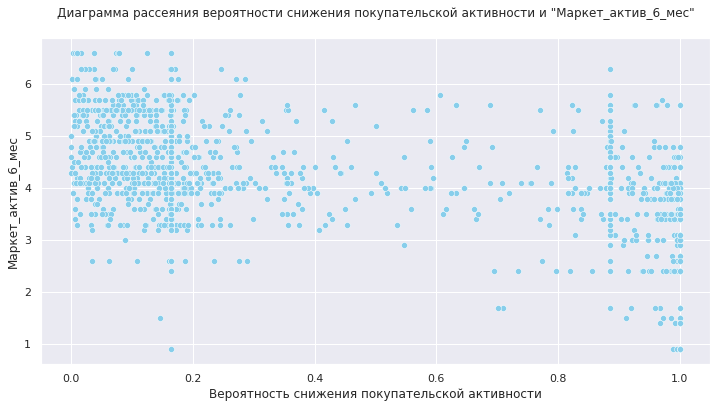

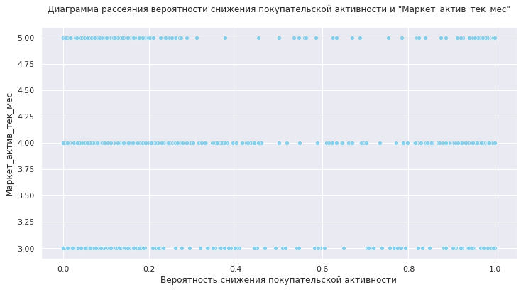

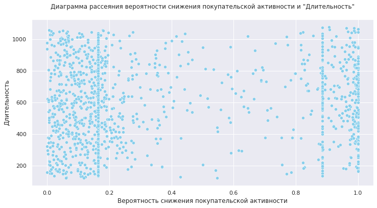

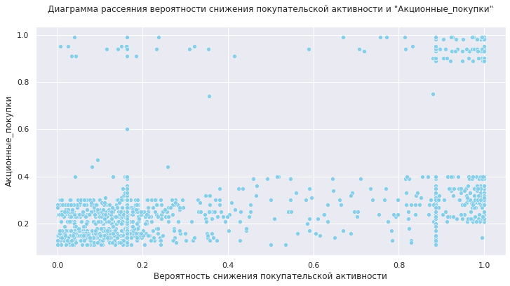

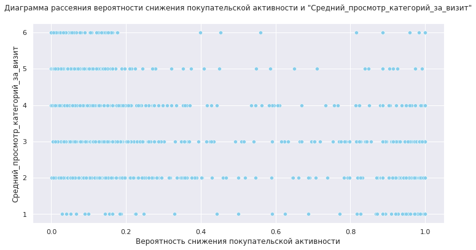

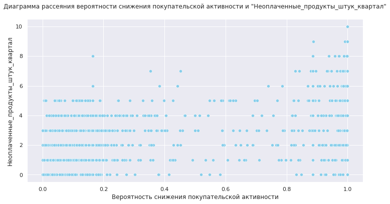

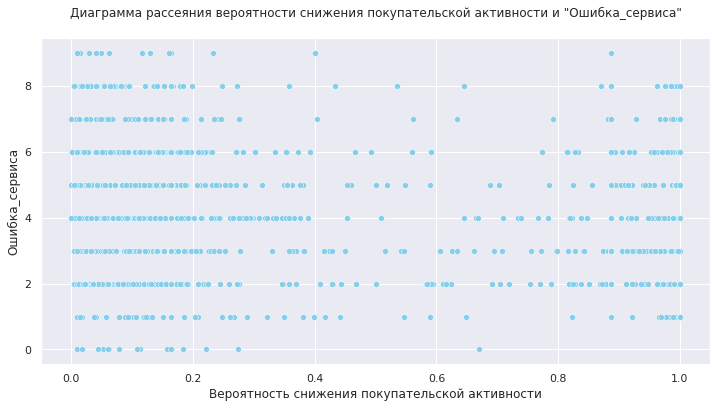

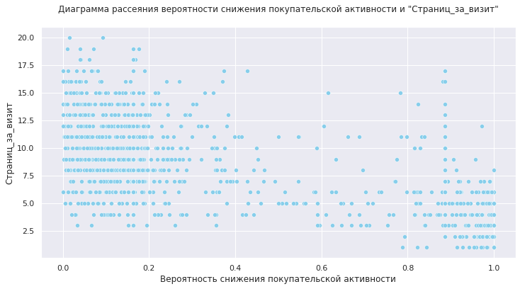

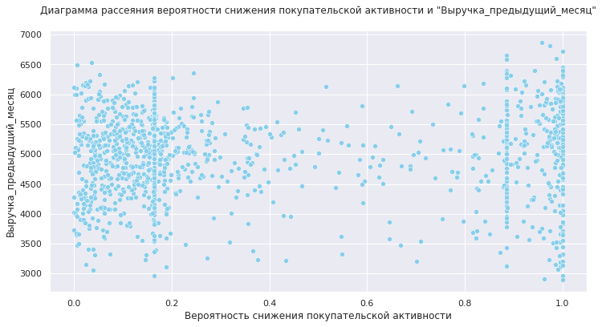

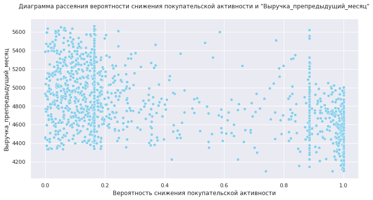

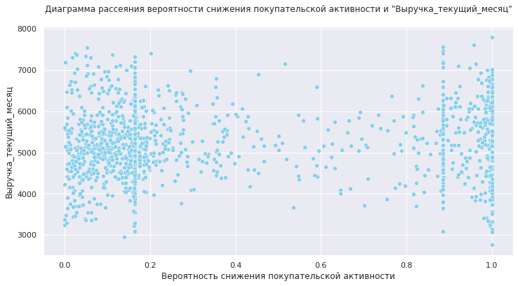

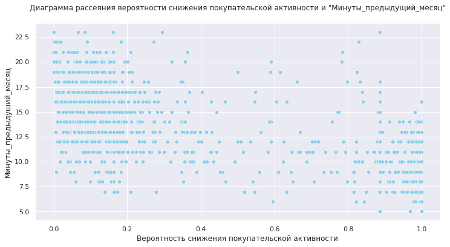

[2 more figures not shown]

```python
for x in df.select_dtypes(include='number').drop('Вероятность_снижения', axis=1).columns:
    plt.figure(figsize=(12, 6))
    sns.scatterplot(data=df, x='Вероятность_снижения', y=x, color='skyblue')
    plt.xlabel('Вероятность снижения покупательской активности')
    plt.title(f'Диаграмма рассеяния вероятности снижения покупательской активности и "{x}"\n')
```

Для нашего дальнейшего исследования выделим сегмент покупателей, которые просматривают менее 10 страниц за один визит, в среднем, за последние 3 месяца и которые имеют высокую вероятность снижения покупательской активности (более 0,6).

```python
seg_df = df.query('(Страниц_за_визит < 10) & (Вероятность_снижения > 0.6)')
seg_df
```

| id | Тип сервиса | Разрешить сообщать | Маркет_актив_6_мес | Маркет_актив_тек_мес | Длительность | Акционные_покупки | Популярная_категория | Средний_просмотр_категорий_за_визит | Неоплаченные_продукты_штук_квартал | Ошибка_сервиса | Страниц_за_визит | Выручка_предыдущий_месяц | Выручка_препредыдущий_месяц | Выручка_текущий_месяц | Минуты_предыдущий_месяц | Минуты_текущий_месяц | Вероятность_снижения | Прибыль |
| --- | --- | --- | --- | --- | --- | --- | --- | --- | --- | --- | --- | --- | --- | --- | --- | --- | --- | --- |
| 215349 | Премиум | Да | 4.4 | 4 | 819 | 0.75 | Товары для детей | 4 | 4 | 2 | 5 | 5216.0 | 4472.0 | 4971.6 | 12 | 10 | 0.879 | 4.16 |
| 215350 | Стандарт | Нет | 4.9 | 3 | 539 | 0.14 | Домашний текстиль | 5 | 2 | 1 | 5 | 5457.5 | 4826.0 | 5058.4 | 8 | 13 | 0.649 | 3.13 |
| 215351 | Стандарт | Да | 3.2 | 5 | 896 | 0.99 | Товары для детей | 5 | 0 | 6 | 4 | 6158.0 | 4793.0 | 6610.4 | 11 | 13 | 0.925 | 4.87 |
| 215352 | Стандарт | Нет | 5.1 | 3 | 1064 | 0.94 | Товары для детей | 3 | 2 | 3 | 2 | 5807.5 | 4594.0 | 5872.5 | 8 | 11 | 0.909 | 4.21 |
| 215354 | Стандарт | Да | 5.1 | 3 | 431 | 0.23 | Косметика и аксcесуары | 2 | 3 | 7 | 2 | 5685.0 | 4503.0 | 5869.6 | 11 | 12 | 0.792 | 3.62 |
| ... | ... | ... | ... | ... | ... | ... | ... | ... | ... | ... | ... | ... | ... | ... | ... | ... | ... | ... |
| 215932 | Стандарт | Нет | 5.3 | 4 | 238 | 0.28 | Товары для детей | 1 | 5 | 2 | 4 | 3350.0 | 4445.0 | 4429.0 | 11 | 6 | 0.872 | 3.17 |
| 215934 | Стандарт | Нет | 5.5 | 4 | 147 | 0.99 | Мелкая бытовая техника и электроника | 1 | 2 | 3 | 7 | 5090.0 | 4451.0 | 5773.8 | 15 | 18 | 0.771 | 4.40 |
| 215939 | Стандарт | Да | 2.6 | 3 | 966 | 0.21 | Товары для детей | 3 | 1 | 6 | 9 | 4709.5 | 5509.0 | 4146.6 | 15 | 22 | 0.774 | 2.57 |
| 216115 | Стандарт | Нет | 4.4 | 4 | 808 | 0.17 | Мелкая бытовая техника и электроника | 4 | 2 | 0 | 3 | 4802.5 | 4543.0 | 5157.4 | 11 | 9 | 0.670 | 4.06 |
| 216636 | Премиум | Да | 2.4 | 4 | 996 | 0.23 | Кухонная посуда | 3 | 4 | 5 | 6 | 5644.5 | 4860.0 | 6454.4 | 10 | 14 | 0.914 | 4.25 |

370 rows × 18 columns

Рассмотрим распределение признаков выделенного сегмента по сравнению с распределением всех данных. Для этого рассмотрим сначала сравнение по категориальным признакам, а затем по количественным.

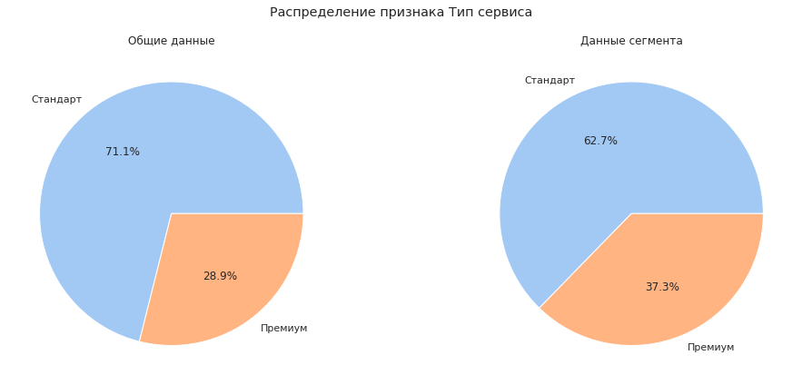

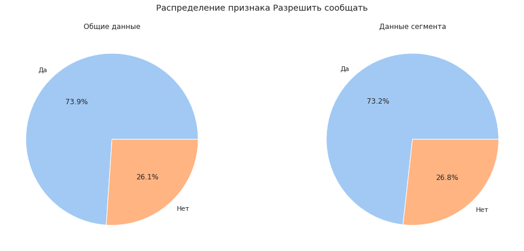

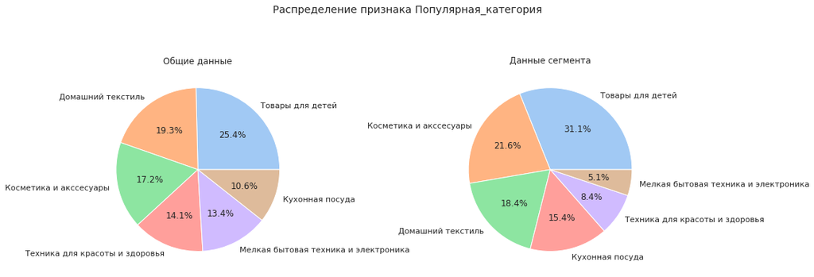

```python
sns.set_theme(palette='pastel')
for column in seg_df.select_dtypes(exclude='number').columns:
    fig, axes = plt.subplots(1, 2, figsize=(15, 6))
    plt.suptitle(f'Распределение признака {column}')
    df[column].value_counts().plot.pie(ax=axes[0], autopct='%.1f%%', ylabel='')
    axes[0].set_title('Общие данные')
    seg_df[column].value_counts().plot.pie(ax=axes[1], autopct='%.1f%%', ylabel='')
    axes[1].set_title('Данные сегмента')
    fig.tight_layout();
```

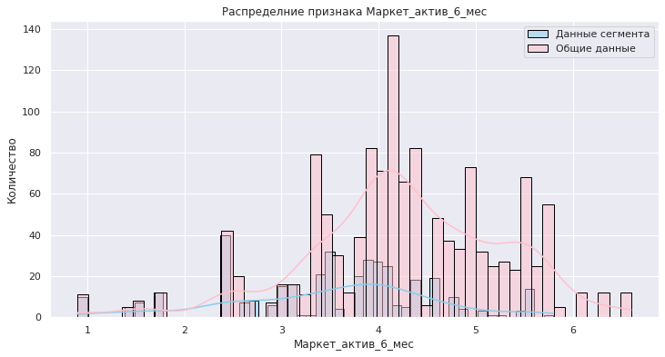

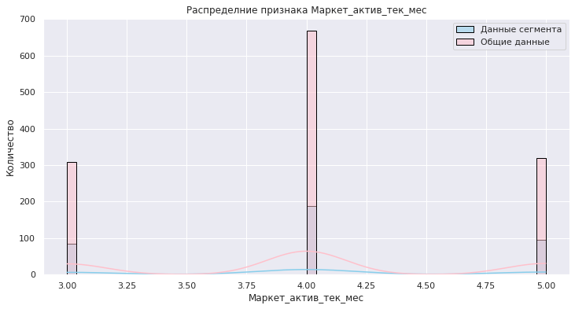

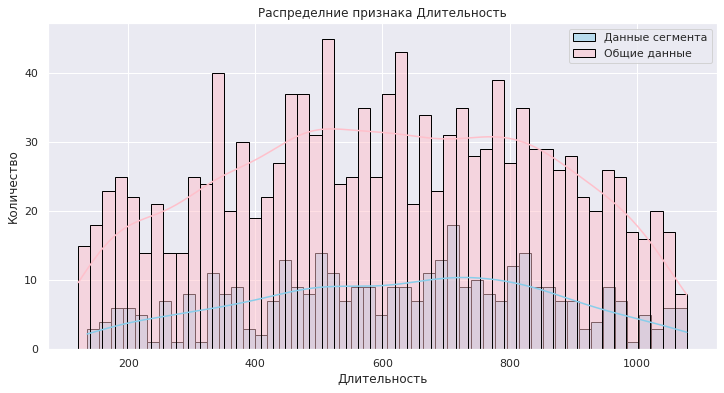

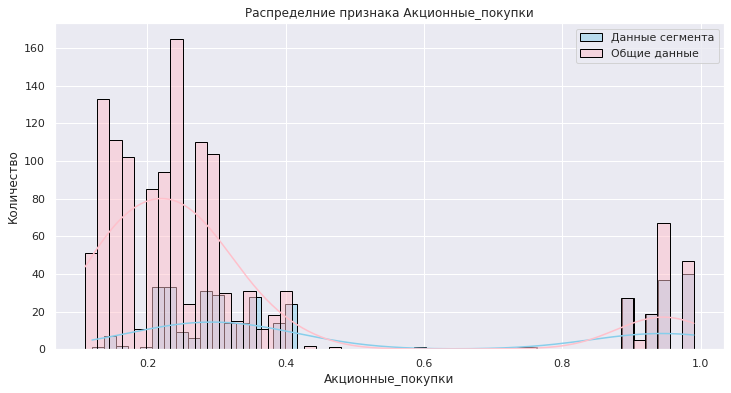

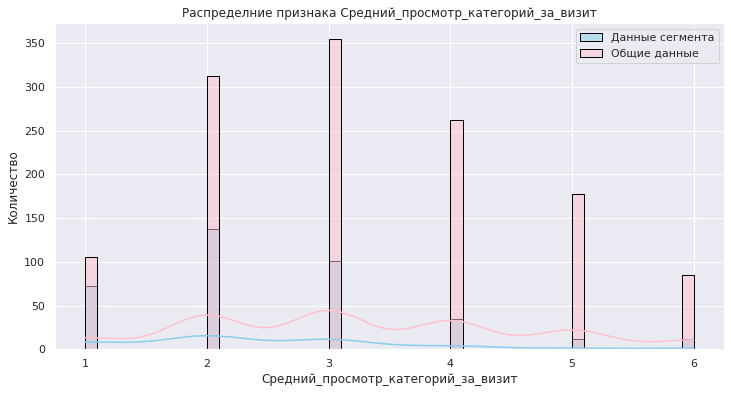

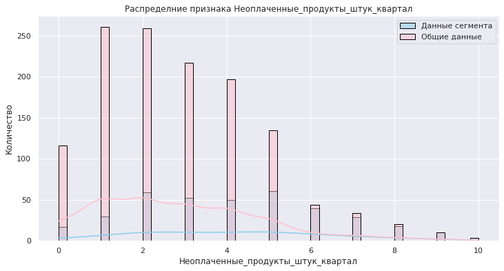

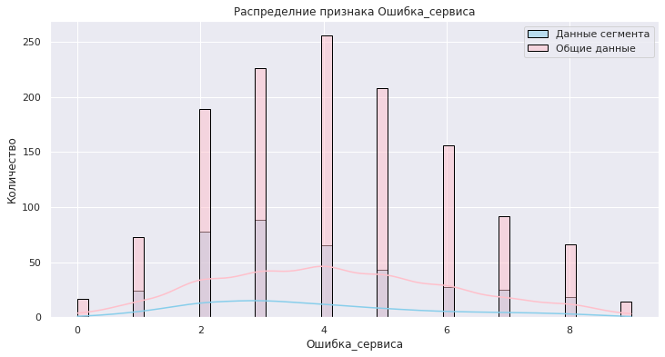

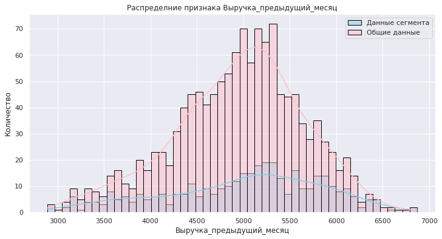

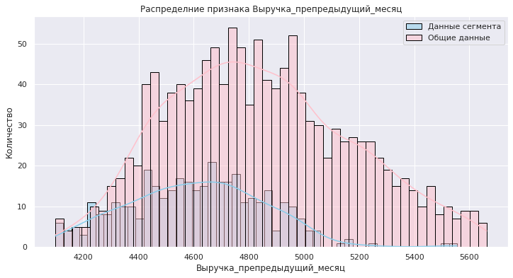

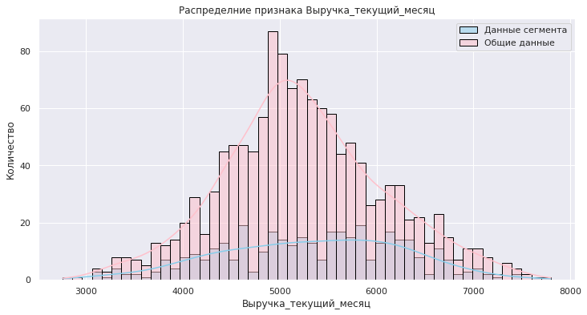

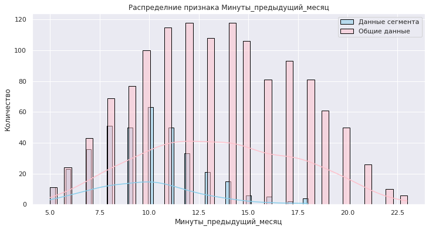

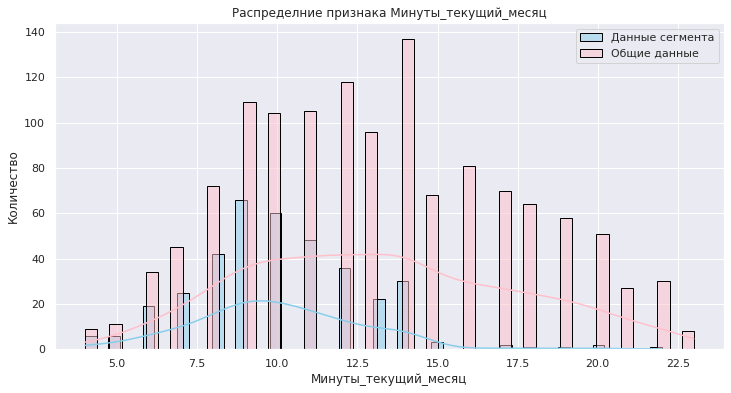

[2 more figures not shown]

```python
for column in seg_df.select_dtypes(include='number').drop('Страниц_за_визит', axis=1).columns:
    plt.figure(figsize=(12, 6))
    plt.title(f'Распределние признака {column}')
    sns.histplot(seg_df[column], bins=50, color='skyblue', edgecolor='black', alpha=0.5, kde=True, label='Данные сегмента')
    sns.histplot(df[column], bins=50, color='pink', edgecolor='black', alpha=0.5, kde=True, label='Общие данные')
    plt.ylabel('Количество')
    plt.legend()
```

Покупатели сегмента, в среднем, получают меньше коммуникаций компании, чем остальные, совершают больше покупок по акции, меньше сталкиваются со сбоями сервиса, что логично, т.к они меньше проводят время на сайте. Также стоит отметить, что покупатели сегмента, в целом, чаще имеют 5 и более товаров в корзине, чем все пользователи в общем.

Типичный покупатель сегмента представляет собой следующую характеристику:

- Низкий уровень коммуникаций: Эти покупатели получают меньше рекламных и информационных сообщений от компании по сравнению с остальными пользователями. Это значит что магазин не предоставляет им каких либо дополнительных источников получения информации о скидках.
- Частые покупки по акциям: Они активно используют акции и специальные предложения. Это может указывать на их стремление к экономии и поиску выгодных предложений.
- Меньше сбоев в сервисе: Данный сегмент реже испытывает проблемы со службой поддержки или другими аспектами сервиса. Это может быть связано с тем, что они меньше времени проводят на сайте, избегая потенциальных ситуаций, связанных с ошибками.
- Большой размер корзины: В среднем, эти покупатели чаще имеют 5 и более товаров в корзине при покупках, что предполагает большее количество товаров на одного покупателя по сравнению с общей аудиторией. Это может указывать на их интерес к большим покупкам или необходимости удовлетворять конкретные потребности.

Таким образом, в качестве предложений по работе с данным сегментом покупателей для увеличения покупательской активности выделим следующие мероприятия:

- Увеличение взаимодействия через каналы связи: Увеличить объем коммуникаций с сегментом, включая информационные рассылки и уведомления о новинках, чтобы поддерживать интерес и информировать о специальных предложениях.
- Разработать целевые предложениями и скидки, учитывающие историю покупок и предпочтения клиентов данного сегмента. Это позволит привлечь их внимание и стимулировать покупки.
- Лояльностные программы: Ввести программы лояльности с накопительными бонусами или скидками для постоянных покупателей. Это будет стимулировать повторные покупки и укреплять привязанность к бренду.
- Стимулирование крупных покупок: Создавать специальные предложения для покупателей, которые добавляют в корзину 5 и более товаров, например, предоставляя дополнительные скидки или бесплатную доставку.

## Выводы

Задачей данного иссследования было построение модели, которая бы предсказала уменьшение покупательской активности пользователей интернет-магазина "В один клик", а также выделений из покупателей перспективного сегмента для увеличения их покупательской активности с последующим анализом.

В рамках исследования были выполнены следующие шаги:

1. **Загрузка данных:**
   - В датасете *df_market* 1300 сточки и 13 признаков. У столбцов `id`, `Маркет_актив_тек_мес`, `Длительность`, `Средний_просмотр_категорий_за_визит`, `Неоплаченные_продукты_штук_квартал`, `Ошибка_сервиса` и `Страниц_за_визит` тип данных int64, у столбцов `Маркет_актив_6_мес`, `Акционные_покупки` - float64, у остальных - object. Пропусков в данных нет.
   - В датасете *df_market_money* 3900 сточек и 3 признака. У столбца `id` целочисленный тип данных int64, у столбца `Выручка`- float64, у `Период` - object. Пропусков в данных нет.
   - В датасете *df_time* 2600 сточек и 3 признака. У столбца `id` и `минут` целочисленный тип данных int64, у `Период` - object. Пропусков в данных нет.
   - В датасете *df_money* 1300 сточек и 2 признака. У столбца `id` тип данных int64, у `Прибыль` - float64. Пропусков в данных нет.
2. **Предобработка данных:**
   - В датасете *df_market* было заменено значение **стандартт** на **стандарт** в столбце `Тип сервиса`, в столбцах `Тип сервиса` и `Разрешить сообщать` значения были отформатированы на слова с большой буквы и была исправлена опечатка в столбце `Популярная_категория`. Полных строк-дубликатов найдено не было;
   - В датасете *df_market_money* дубликатов не обнаружено;
   - В датасете *df_time* было отформатировано название столбцы `Минут`, а также исправлена опечатка в значениях столбца `Период`. Полных строк-дубликатов обнаружено не было;
   - В датасете *df_money* строк-дубликатов обнаружено не было.
3. **Исследовательский анализ:**  
   На этом этапе были построены диаграммы распределения всех признаков. Обнаружено незначительное количество явных аномалий, которые были исключены из анализа. Также оставлены только те пользователи, которые совершали покупки в течение последних трёх месяцев.
4. **Объединение таблиц:**  
   В ходе объединения были соединены датасеты *df_market*, *df_market_money* и *df_time*. В полученной таблице пропусков не обнаружено.
5. **Корреляционный анализ:**  
   Значения корреляции хи-квадрат обнаружены, в основном, с целевым признаком, из наиболее коррелирующих признаков выделим `Страниц_за_визит`, `Минуты_предыдущий_месяц` и `Минуты_текущий_месяц`. Из остальных признаков выделим корреляцию между признаками `Выручка_текущий_месяц` и `Выручка_предыдущий_месяц`.

   Мультиколлинеарности в данных не обнаружено, т.к. все значения корреляции хи-квадрат меньше 0,9.
6. **Использование пайплайнов:**  
   В ходе моделирования была найдена и обучена модель для определения вероятности снижения покупательской активности клиентов. Лучшие результаты показала модель метода опорных векторов **SVC(C=1, kernel='poly', probability=True, random_state=42)**. Её показатели метрики roc-auc для тренировочной выборки - 0.908, для тестовой выборки - 0.914. Это хорошие показатели, означающие, что модель хорошо справляется со своей задачей.

   Также была рассчитана метрика F1 для тестовой выборки, её знаение - 0,844, что подтверждает, что модель отлично справяется с предсказанием вероятности снижения покупательской активности.
7. **Анализ важности признаков:**  
   Наиболее важные признаки - `Страниц_за_визит`, `Минуты_текущий_месяц`, `Акционные_покупки`, `Неоплаченные_продукты_штук_квартал` и `Минуты_предыдущий_месяц`.

   Признаки, имеющие незначительное влияние на модель - `Популярная_категория`, `Разрешить сообщать`, `Тип сервиса`, `Маркет_актив_тек_мес`.

   При сегментации покупателей был сделан упор на признаки, имеющие наибольшее влияние на модель.
8. **Сегментация покупателей:**

   В ходе сегментации покупателей были описаны типичные покупатели сегмента, они имеют следующую характеристику:
   - Низкий уровень коммуникаций: Эти покупатели получают меньше рекламных и информационных сообщений от компании по сравнению с остальными пользователями. Это значит что магазин не предоставляет им каких либо дополнительных источников получения информации о скидках.
   - Частые покупки по акциям: Они активно используют акции и специальные предложения. Это может указывать на их стремление к экономии и поиску выгодных предложений.
   - Меньше сбоев в сервисе: Данный сегмент реже испытывает проблемы со службой поддержки или другими аспектами сервиса. Это может быть связано с тем, что они меньше времени проводят на сайте, избегая потенциальных ситуаций, связанных с ошибками.
   - Большой размер корзины: В среднем, эти покупатели чаще имеют 5 и более товаров в корзине при покупках, что предполагает большее количество товаров на одного покупателя по сравнению с общей аудиторией. Это может указывать на их интерес к большим покупкам или необходимости удовлетворять конкретные потребности.

Таким образом, для увеличения покупательской активности этого сегмента были предложены следующие мероприятия:

- Увеличение взаимодействия через каналы связи: Увеличить объем коммуникаций с сегментом, включая информационные рассылки и уведомления о новинках, чтобы поддерживать интерес и информировать о специальных предложениях.
- Разработать целевые предложениями и скидки, учитывающие историю покупок и предпочтения клиентов данного сегмента. Это позволит привлечь их внимание и стимулировать покупки.
- Лояльностные программы: Ввести программы лояльности с накопительными бонусами или скидками для постоянных покупателей. Это будет стимулировать повторные покупки и укреплять привязанность к бренду.
- Стимулирование крупных покупок: Создавать специальные предложения для покупателей, которые добавляют в корзину 5 и более товаров, например, предоставляя дополнительные скидки или бесплатную доставку.